# R Notebook

Charger les bibliothèques nécessaires

```r
library(dplyr)
library(readr)
library(stringr)
```

Definir le repertoire de travail

```r
setwd("/home/lnsp/Bureau/training_ghana/Travaux_pratique/rvf_africa_projet/donnees")  # Remplace par ton chemin réel

fichier <- "rvf_africa.tsv"

donnees <- read_tsv(fichier, show_col_types = FALSE)

print(colnames(donnees))
```

```
##  [1] "Species"            "GenomeStatus"       "Strain"
##  [4] "Segment"            "GenBank Accessions" "Size"
##  [7] "GC Content"         "Contig N50"         "CollectionDate"
## [10] "CollectionYear"     "IsolationCountry"   "GeographicGroup"
## [13] "HostName"           "Host Common Name"   "HostGroup"
```

Étape 1 : Retirer les entrées sans date de collecte ou pays

```r
donnees_filtrees <- donnees %>%
  filter(!is.na(CollectionDate), !is.na(IsolationCountry))

# Sauvegarder les données filtrées
write_tsv(donnees_filtrees, "donnees_filtrees.tsv")
```

Étape 2 : Grouper et résumer le nombre de séquences par pays, année, segment

```r
resume_pays_annee_segment <- donnees_filtrees %>%
  group_by(IsolationCountry, CollectionYear, Segment) %>%
  summarise(Nb_sequences = n(), .groups = "drop")

write_tsv(resume_pays_annee_segment, "resume_pays_annee_segment.tsv")
print(resume_pays_annee_segment)
```

```
## # A tibble: 246 × 4
##    IsolationCountry CollectionYear Segment Nb_sequences
##    <chr>                     <dbl> <chr>          <int>
##  1 Angola                     1985 M                  1
##  2 Angola                     1985 S                  1
##  3 Angola                     2016 L                  1
##  4 Angola                     2016 M                  1
##  5 Angola                     2016 S                  1
##  6 Burkina Faso               1983 L                  1
##  7 Burkina Faso               1983 M                  1
##  8 Burkina Faso               1983 S                  2
##  9 Burundi                    2022 L                  5
## 10 Burundi                    2022 M                  7
## # ℹ 236 more rows
```

Étape 3 : Créer une colonne dérivée (par exemple : région depuis le pays)

```r
donnees_mutation <- donnees_filtrees %>%
  mutate(Region = case_when(
    IsolationCountry %in% c("Kenya", "Sudan", "Tanzania", "Uganda") ~ "Afrique de l'Est",
    IsolationCountry %in% c("Senegal", "Mauritania") ~ "Afrique de l'Ouest",
    TRUE ~ "Autre"
  ))
```

Etape 4: compter le nombre de sequences par hote commun

```r
compte_hotes <- donnees_mutation %>%
  group_by(`Host Common Name`) %>%
  summarise(Nb_sequences = n(), .groups = "drop") %>%
  arrange(desc(Nb_sequences))

write_tsv(compte_hotes, "compte_hotes.tsv")
print(compte_hotes)
```

```
## # A tibble: 16 × 2
##    `Host Common Name`      Nb_sequences
##    <chr>                          <int>
##  1 Human                            769
##  2 Cow                              243
##  3 Mosquito                         131
##  4 <NA>                             130
##  5 Sheep                             70
##  6 Goat                              18
##  7 Buffalo                            9
##  8 Bat                                7
##  9 Null                               6
## 10 Cattle                             5
## 11 Camel                              3
## 12 Mouse                              3
## 13 Tick                               3
## 14 Lab host                           1
## 15 Northern House Mosquito            1
## 16 Sand fly                           1
```

Étape 5 : Filtrer par pays, années et segments spécifiques (exemple : Kenya, 2007, segment L)

```r
filtres_specifiques <- donnees_mutation %>%
  filter(IsolationCountry == "Kenya", CollectionYear == 2007, Segment == "L")

print(filtres_specifiques)
```

```
## # A tibble: 44 × 16
##    Species   GenomeStatus Strain Segment `GenBank Accessions`  Size `GC Content`
##    <chr>     <chr>        <chr>  <chr>   <chr>                <dbl>        <dbl>
##  1 Phlebovi… Partial      K2     L       PP746417              6386         43.8
##  2 Phlebovi… Partial      J8     L       PP746426              6251         43.6
##  3 Phlebovi… Partial      J10    L       PP746425              6232         43.5
##  4 Phlebovi… Partial      J9     L       PP746427              6277         43.5
##  5 Phlebovi… Partial      KEM-JC L       PP746437              6268         43.5
##  6 Phlebovi… Partial      KEM-BR L       PP746436              6232         43.5
##  7 Phlebovi… Partial      KEM-ND L       PP746438              6232         43.4
##  8 Phlebovi… Partial      MO-LE  L       PP746448              6387         43.5
##  9 Phlebovi… Partial      HA-HAR L       PP746447              6373         43.9
## 10 Phlebovi… Partial      MSA    L       PP746449              6388         43.4
## # ℹ 34 more rows
## # ℹ 9 more variables: `Contig N50` <dbl>, CollectionDate <chr>,
## #   CollectionYear <dbl>, IsolationCountry <chr>, GeographicGroup <chr>,
## #   HostName <chr>, `Host Common Name` <chr>, HostGroup <chr>, Region <chr>
```

Étape 6 : Renommer la colonne CollectionYear en year

```r
donnees_renommee <- donnees_mutation %>%
  rename(year = CollectionYear)
```

Étape 7 : Grouper et résumer par pays, année et segment

```r
resume_final <- donnees_renommee %>%
  group_by(IsolationCountry, year, Segment) %>%
  summarise(Nb_sequences = n(), .groups = "drop")

write_tsv(resume_final, "resume_final.tsv")
print(resume_final)
```

```
## # A tibble: 246 × 4
##    IsolationCountry  year Segment Nb_sequences
##    <chr>            <dbl> <chr>          <int>
##  1 Angola            1985 M                  1
##  2 Angola            1985 S                  1
##  3 Angola            2016 L                  1
##  4 Angola            2016 M                  1
##  5 Angola            2016 S                  1
##  6 Burkina Faso      1983 L                  1
##  7 Burkina Faso      1983 M                  1
##  8 Burkina Faso      1983 S                  2
##  9 Burundi           2022 L                  5
## 10 Burundi           2022 M                  7
## # ℹ 236 more rows
```

Étape 8 : Identifier les pays avec le plus grand nombre de séquences complètes (indépendamment du segment)

```r
pays_plus_sequences <- donnees_filtrees %>%
  filter(GenomeStatus == "Complete") %>%
  group_by(IsolationCountry) %>%
  summarise(Nb_sequences_completes = n(), .groups = "drop") %>%
  arrange(desc(Nb_sequences_completes))

write_tsv(pays_plus_sequences, "pays_plus_sequences.tsv")
print(pays_plus_sequences)
```

```
## # A tibble: 19 × 2
##    IsolationCountry         Nb_sequences_completes
##    <chr>                                     <int>
##  1 South Africa                                389
##  2 Kenya                                       178
##  3 Madagascar                                   38
##  4 Zimbabwe                                     35
##  5 Central African Republic                     33
##  6 Egypt                                        33
##  7 Uganda                                       28
##  8 Sudan                                        22
##  9 Mauritania                                   15
## 10 Namibia                                      12
## 11 Tanzania                                     12
## 12 Guinea                                        7
## 13 Senegal                                       7
## 14 Angola                                        4
## 15 Burkina Faso                                  4
## 16 Gabon                                         4
## 17 Mayotte                                       2
## 18 Somalia                                       1
## 19 Zambia                                        1
```

Étape 9 : Compter les hôtes les plus fréquents (top 10)

```r
top_hotes <- donnees_filtrees %>%
  group_by(`Host Common Name`) %>%
  summarise(Nb_sequences = n(), .groups = "drop") %>%
  arrange(desc(Nb_sequences)) %>%
  slice_head(n = 10)

write_tsv(top_hotes, "top_hotes.tsv")
print(top_hotes)
```

```
## # A tibble: 10 × 2
##    `Host Common Name` Nb_sequences
##    <chr>                     <int>
##  1 Human                       769
##  2 Cow                         243
##  3 Mosquito                    131
##  4 <NA>                        130
##  5 Sheep                        70
##  6 Goat                         18
##  7 Buffalo                       9
##  8 Bat                           7
##  9 Null                          6
## 10 Cattle                        5
```

```r
cat("✅ Analyse terminée. Tous les fichiers résumés ont été sauvegardés dans le répertoire : ", getwd(), "\n")
```

```
## ✅ Analyse terminée. Tous les fichiers résumés ont été sauvegardés dans le répertoire :  /home/lnsp/Bureau/training_ghana/Travaux_pratique/rvf_africa_projet/resultats
```

Telechargement de librairie

```r
library(dplyr)
library(readr)
# repertoire de travail

setwd("/home/lnsp/Bureau/training_ghana/Travaux_pratique/rvf_africa_projet/resultats")

donnees <- read_tsv(fichier, show_col_types = FALSE)

print(colnames(donnees))
```

```
##  [1] "Species"            "GenomeStatus"       "Strain"
##  [4] "Segment"            "GenBank Accessions" "Size"
##  [7] "GC Content"         "Contig N50"         "CollectionDate"
## [10] "CollectionYear"     "IsolationCountry"   "GeographicGroup"
## [13] "HostName"           "Host Common Name"   "HostGroup"
```

1️⃣ Nombre d’isolats par pays

```r
isolats_par_pays <- donnees %>%
  group_by(IsolationCountry) %>%
  summarise(Nombre_isolats = n(), .groups = "drop") %>%
  arrange(desc(Nombre_isolats))
print("=== Nombre d'isolats par pays ===")
```

```
## [1] "=== Nombre d'isolats par pays ==="
```

```r
print(isolats_par_pays)
```

```
## # A tibble: 25 × 2
##    IsolationCountry         Nombre_isolats
##    <chr>                             <int>
##  1 South Africa                        434
##  2 Kenya                               260
##  3 Madagascar                          198
##  4 Mauritania                          118
##  5 Uganda                              111
##  6 Senegal                              52
##  7 Egypt                                51
##  8 Zimbabwe                             51
##  9 Central African Republic             37
## 10 Sudan                                23
## # ℹ 15 more rows
```

Sauvegarder le résumé

```r
write_tsv(isolats_par_pays, "nombre_isolats_par_pays.tsv")
```

2️⃣ Nombre d’isolats par an

```r
isolats_par_an <- donnees %>%
  group_by(CollectionYear) %>%
  summarise(Nombre_isolats = n(), .groups = "drop") %>%
  arrange(CollectionYear)
print("=== Nombre d'isolats par an ===")
```

```
## [1] "=== Nombre d'isolats par an ==="
```

```r
print(isolats_par_an)
```

```
## # A tibble: 54 × 2
##    CollectionYear Nombre_isolats
##             <dbl>          <int>
##  1           1944             10
##  2           1951              8
##  3           1955             24
##  4           1956              4
##  5           1962              5
##  6           1963              2
##  7           1964              1
##  8           1965              1
##  9           1969             11
## 10           1970              5
## # ℹ 44 more rows
```

```r
write_tsv(isolats_par_an, "nombre_isolats_par_an.tsv")
```

3️⃣ Répartition des segments (S, M, L) par pays

```r
repartition_segments <- donnees %>%
  group_by(IsolationCountry, Segment) %>%
  summarise(Nombre = n(), .groups = "drop") %>%
  arrange(IsolationCountry, Segment)

print("=== Répartition des segments par pays ===")
```

```
## [1] "=== Répartition des segments par pays ==="
```

```r
print(repartition_segments)
```

```
## # A tibble: 67 × 3
##    IsolationCountry         Segment Nombre
##    <chr>                    <chr>    <int>
##  1 Angola                   L            1
##  2 Angola                   M            2
##  3 Angola                   S            2
##  4 Burkina Faso             L            1
##  5 Burkina Faso             M            1
##  6 Burkina Faso             S            2
##  7 Burundi                  L            5
##  8 Burundi                  M            7
##  9 Burundi                  <NA>         5
## 10 Central African Republic L           11
## # ℹ 57 more rows
```

```r
# Sauvegarder le résumé
write_tsv(repartition_segments, "repartition_segments_par_pays.tsv")

cat("✅ Analyse descriptive terminée. Résultats sauvegardés dans le dossier : ",
    getwd(), "\n")
```

```
## ✅ Analyse descriptive terminée. Résultats sauvegardés dans le dossier :  /home/lnsp/Bureau/training_ghana/Travaux_pratique/rvf_africa_projet/resultats
```

Assurez-vous que les colonnes sont bien de type approprié

```r
donnees <- donnees %>%
  mutate(CollectionYear = as.integer(CollectionYear),
         CollectionDate = as.Date(CollectionDate, format = "%Y-%m-%d"))
```

Visualisation des données

1️⃣ Boxplot : distribution des dates de collecte par pays

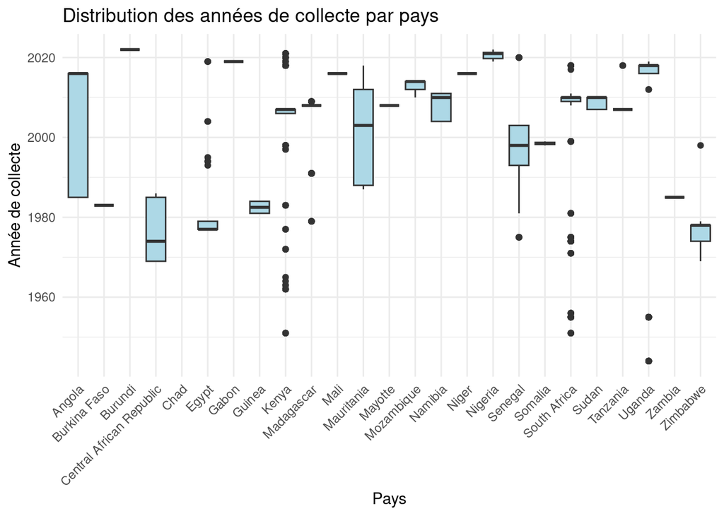

```r
library(ggplot2)

ggplot(donnees, aes(x = IsolationCountry, y = CollectionYear)) +
  geom_boxplot(fill = "lightblue") +
  labs(title = "Distribution des années de collecte par pays",
       x = "Pays",
       y = "Année de collecte") +
  theme_minimal() +
  theme(axis.text.x = element_text(angle = 45, hjust = 1))
```

```r
ggsave("boxplot_annee_par_pays.png", width = 8, height = 5)
```

2️⃣ Boxplot : distribution des années de collecte par segment

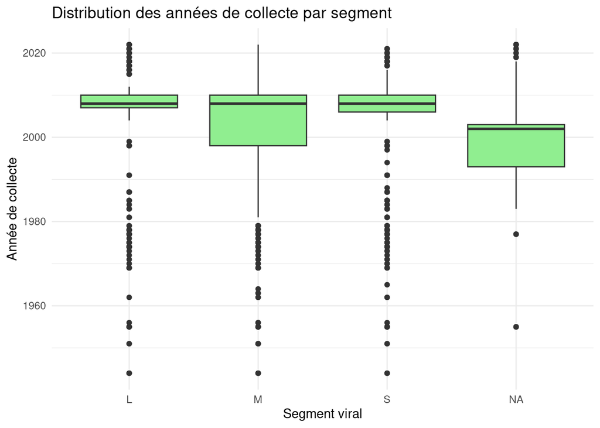

```r
ggplot(donnees, aes(x = Segment, y = CollectionYear)) +
  geom_boxplot(fill = "lightgreen") +
  labs(title = "Distribution des années de collecte par segment",
       x = "Segment viral",
       y = "Année de collecte") +
  theme_minimal()
```

```r
ggsave("boxplot_annee_par_segment.png", width = 6, height = 5)
```

3️⃣ Résumé : nombre d’isolats par pays et année

```r
resume_pays_annee <- donnees %>%
  group_by(IsolationCountry, CollectionYear) %>%
  summarise(Nb_isolats = n(), .groups = "drop") %>%
  arrange(desc(Nb_isolats))

print("Résumé des isolats par pays et année :")
```

```
## [1] "Résumé des isolats par pays et année :"
```

```r
print(resume_pays_annee)
```

```
## # A tibble: 113 × 3
##    IsolationCountry CollectionYear Nb_isolats
##    <chr>                     <int>      <int>
##  1 South Africa               2010        279
##  2 Madagascar                 2008        171
##  3 Kenya                      2007        152
##  4 Uganda                     2018         49
##  5 South Africa               2008         35
##  6 Kenya                      2006         27
##  7 Mauritania                 1987         27
##  8 South Africa               2011         27
##  9 Zimbabwe                   1978         27
## 10 South Africa               2009         26
## # ℹ 103 more rows
```

```r
write_tsv(resume_pays_annee, "resume_isolats_par_pays_annee.tsv")
```

4️⃣ Barplot : distribution des souches par pays

[figure not shown]

```r
ggplot(donnees, aes(x = IsolationCountry, fill = Strain)) +
  geom_bar(position = "dodge") +
  labs(title = "Distribution des souches par pays",
       x = "Pays",
       y = "Nombre d’isolats",
       fill = "Souche (Strain)") +
  theme_minimal() +
  theme(axis.text.x = element_text(angle = 45, hjust = 1))
```

```r
ggsave("barplot_souches_par_pays.png", width = 8, height = 5)

cat("✅ Graphiques générés et sauvegardés dans : ", getwd(), "\n")
```

```
## ✅ Graphiques générés et sauvegardés dans :  /home/lnsp/Bureau/training_ghana/Travaux_pratique/rvf_africa_projet/resultats
```